# Lab 04 Text Analysis

## Environment

### Part One:

```r
dat$activity.code <- paste0(dat$codedef01, ": ", dat$codedef02)
grep("^environment", dat$activity.code, value = TRUE, ignore.case = T) %>% head(10)
```

```
 [1] "Environmental Quality Protection, Beautification: Natural Resource Conservation and Protection"
 [2] "Environmental Quality Protection, Beautification: Natural Resource Conservation and Protection"
 [3] "Environmental Quality Protection, Beautification: Natural Resource Conservation and Protection"
 [4] "Environmental Quality Protection, Beautification: Natural Resource Conservation and Protection"
 [5] "Environmental Quality Protection, Beautification: Natural Resource Conservation and Protection"
 [6] "Environmental Quality Protection, Beautification: Natural Resource Conservation and Protection"
 [7] "Environmental Quality Protection, Beautification: Natural Resource Conservation and Protection"
 [8] "Environmental Quality Protection, Beautification: Natural Resource Conservation and Protection"
 [9] "Environmental Quality Protection, Beautification: Natural Resource Conservation and Protection"
[10] "Environmental Quality Protection, Beautification: Natural Resource Conservation and Protection"
```

```r
category3 <- grepl("^environment", dat$activity.code, ignore.case = T)
sum(category3)
```

```
[1] 922
```

```r
dat3 <- dat[category3, c("orgname", "activity.code", "mission")]
dat3 %>% head(10) %>% pander()
```

Table continues below

|  | orgname | activity.code |
| --- | --- | --- |
| **40770** | KAI OLA MOLOKAI | Environmental Quality Protection, Beautification: Natural Resource Conservation and Protection |
| **40771** | BEE HARMONY | Environmental Quality Protection, Beautification: Natural Resource Conservation and Protection |
| **40772** | THE FOUNDATION FOR INDIGENOUS MEDICINE INC | Environmental Quality Protection, Beautification: Natural Resource Conservation and Protection |
| **40773** | FRIENDS OF LIEBER STATE RECREATIONAREA | Environmental Quality Protection, Beautification: Natural Resource Conservation and Protection |
| **40774** | CAYTON RANGER STATION FOUNDATION815 | Environmental Quality Protection, Beautification: Natural Resource Conservation and Protection |
| **40775** | LONG LIFE INSTITUTE HONEY FUND | Environmental Quality Protection, Beautification: Natural Resource Conservation and Protection |
| **40776** | DIMPLE DELL PRESERVATION COMMUNITY | Environmental Quality Protection, Beautification: Natural Resource Conservation and Protection |
| **40777** | BROOKER CREEK WATERSHED CITIZENS ALLIANCE INC | Environmental Quality Protection, Beautification: Natural Resource Conservation and Protection |
| **40778** | THE BEAR LAKE PRESERVATION ASSOCIATION OF MUSKEGON COUNTY | Environmental Quality Protection, Beautification: Natural Resource Conservation and Protection |
| **40779** | CONSERVANTION | Environmental Quality Protection, Beautification: Natural Resource Conservation and Protection |

|  | mission |
| --- | --- |
| **40770** | Conservation of sustainable reef resources, management of invasive marine species, scientific research |
| **40771** | The conservation, safeguard and re-naturalization of Honey Bees as pollinators by providing Honey Bees with natural, environmental beehives in locations to encourage natural and diverse pollination. P… |
| **40772** |  |
| **40773** | FOL is an independent nonprofit corporation, organized and operated exclusively for charitable, educational, and scientific purposes as outlined in the Articles of Incorporation of Friends of Lieber S… |
| **40774** | The Cayton Ranger StationFoundation is dedicated to the restoration,preservation and enjoyment of the Cayton Ranger Station. |
| **40775** | Education on sustainable agriculture and land management, vocational education |
| **40776** | A nonprofit community education group to host activities and promote public education for the preservation of Dimple Dell Park as a natural, undeveloped wilderness preserve. |
| **40777** | Citizens against pollution, protecting the Brooker Creek Watershed environment. Our most significant activities are educating and seeking legal remedies as necessary to protect the Brooker Creek Water… |
| **40778** | The Bear Lake Preservation Association of Muskegon County is dedicated to the long term improvement and preservation of natural resources in and around Bear Lake. 501(c)3 approval will allow ongoing p… |
| **40779** | ConserVANtion’s mission is to preserve, conserve, and restore native ecosystems that have been susceptible to urbanization, habitat fragmentation, or other negative anthropogenic effects through organ… |

```r
corp.cat3 <- corpus(dat3, docid_field = "orgname", text_field = "mission")
corp.cat3
```

```
Corpus consisting of 922 documents and 1 docvar.
```

```r
corp.cat3[1:5]
```

```
                                                                                                                                                                                                                          KAI OLA MOLOKAI
                                                                                                                                  "Conservation of sustainable reef resources, management of invasive marine species, scientific research"
                                                                                                                                                                                                                              BEE HARMONY
"The conservation, safeguard and re-naturalization of Honey Bees as pollinators by providing Honey Bees with natural, environmental beehives in locations to encourage natural and diverse pollination.  Provide education to the public."
                                                                                                                                                                                                THE FOUNDATION FOR INDIGENOUS MEDICINE INC
                                                                                                                                                                                                                                        ""
                                                                                                                                                                                                    FRIENDS OF LIEBER STATE RECREATIONAREA
         "FOL is an independent nonprofit corporation, organized and operated exclusively for charitable, educational, and scientific purposes as outlined in the Articles of Incorporation of Friends of Lieber State Recreational Area."
                                                                                                                                                                                                      CAYTON RANGER STATION FOUNDATION815
                                                                                                            "The Cayton Ranger StationFoundation is dedicated to the restoration,preservation and enjoyment of the Cayton Ranger Station."
```

```r
# summarize corpus
summary(corp.cat3)[1:10, ]
```

```
                                                        Text Types Tokens
1                                           KAI OLA MOLOKAI     12     14
2                                               BEE HARMONY     28     35
3                 THE FOUNDATION FOR INDIGENOUS MEDICINE INC     0      0
4                     FRIENDS OF LIEBER STATE RECREATIONAREA    29     34
5                       CAYTON RANGER STATION FOUNDATION815     16     19
6                            LONG LIFE INSTITUTE HONEY FUND     10     10
7                        DIMPLE DELL PRESERVATION COMMUNITY     26     27
8              BROOKER CREEK WATERSHED CITIZENS ALLIANCE INC    25     31
9  THE BEAR LAKE PRESERVATION ASSOCIATION OF MUSKEGON COUNTY    38     44
10                                            CONSERVANTION     28     32
   Sentences
1          1
2          2
3          0
```

[output cut: 18 more lines]

```r
# pre-processing steps:

# remove mission statements that are less than 3 sentences long
corp.cat3 <- corpus_trim(corp.cat3, what = "sentences", min_ntoken = 3)
corp.cat3
```

```
Corpus consisting of 829 documents and 1 docvar.
```

```r
# remove punctuation
tokens.cat3 <- tokens(corp.cat3, what = "word", remove_punct = TRUE)

# convert to lower case
tokens.cat3 <- tokens_tolower(tokens.cat3, keep_acronyms = FALSE)
head(tokens.cat3)
```

```
tokens from 6 documents.
KAI OLA MOLOKAI  :
 [1] "conservation" "of"           "sustainable"  "reef"         "resources"
 [6] "management"   "of"           "invasive"     "marine"       "species"
[11] "scientific"   "research"

BEE HARMONY  :
 [1] "the"               "conservation"      "safeguard"
 [4] "and"               "re-naturalization" "of"
 [7] "honey"             "bees"              "as"
[10] "pollinators"       "by"                "providing"
[13] "honey"             "bees"              "with"
[16] "natural"           "environmental"     "beehives"
[19] "in"                "locations"         "to"
[22] "encourage"         "natural"           "and"
```

[output cut: 32 more lines]

```r
# remove common words like a, and, to
tokens.cat3 <- tokens_remove(tokens.cat3, c(stopwords("english"), "nbsp"), padding = F)
head(tokens.cat3)
```

```
tokens from 6 documents.
KAI OLA MOLOKAI  :
 [1] "conservation" "sustainable"  "reef"         "resources"    "management"
 [6] "invasive"     "marine"       "species"      "scientific"   "research"

BEE HARMONY  :
 [1] "conservation"      "safeguard"         "re-naturalization"
 [4] "honey"             "bees"              "pollinators"
 [7] "providing"         "honey"             "bees"
[10] "natural"           "environmental"     "beehives"
[13] "locations"         "encourage"         "natural"
[16] "diverse"           "pollination"       "provide"
[19] "education"         "public"

FRIENDS OF LIEBER STATE RECREATIONAREA :
 [1] "fol"           "independent"   "nonprofit"     "corporation"
 [5] "organized"     "operated"      "exclusively"   "charitable"
 [9] "educational"   "scientific"    "purposes"      "outlined"
[13] "articles"      "incorporation" "friends"       "lieber"
[17] "state"         "recreational"  "area"

CAYTON RANGER STATION FOUNDATION815  :
 [1] "cayton"            "ranger"            "stationfoundation"
 [4] "dedicated"         "restoration"       "preservation"
 [7] "enjoyment"         "cayton"            "ranger"
[10] "station"

LONG LIFE INSTITUTE HONEY FUND  :
[1] "education"   "sustainable" "agriculture" "land"        "management"
[6] "vocational"  "education"

DIMPLE DELL PRESERVATION COMMUNITY  :
 [1] "nonprofit"    "community"    "education"    "group"        "host"
 [6] "activities"   "promote"      "public"       "education"    "preservation"
[11] "dimple"       "dell"         "park"         "natural"      "undeveloped"
[16] "wilderness"   "preserve"
```

```r
my_dictionary3 <- dictionary(list(five01_c_3 = c("501 c 3", "section 501 c 3"), united_states = c("united states"),
    high_school = c("high school"), non_profit = c("non-profit", "non profit"), stem = c("science technology engineering math",
        "science technology engineering mathematics"), los_angeles = c("los angeles"),
    ny_state = c("new york state"), ny = c("new york"), san_francisco = c("san francisco"),
    san_diego = c("san diego"), north_carolina = c("north carolina"), south_carolina = c("south carolina"),
    dc = c("district of columbia"), north_dakota = c("north dakota"), south_dakota = c("south dakota"),
    west_virginia = c("west virginia"), new_mexico = c("new mexico"), new_hampshire = c("new hampshire"),
    new_jersey = c("new jersey"), new_england = c("new england"), high_quality = c("high-quality",
        "high quality"), low_income = c("low income", "low-income"), early_childhood = c("early childhood",
        "early-childhood"), community_based = c("community-based", "community based"),
    mission_driven = c("mission-driven", "mission driven"), ses = c("socioeconomic status"),
    performing_arts = c("performing arts"), honeybees = c("honey bees"), forest_preserve = c("forest preserve"),
    water_conservation = c("water conservation")))

# apply the dictionary to the text
tokens.cat3 <- tokens_compound(tokens.cat3, pattern = my_dictionary3)
head(tokens.cat3)
```

```
tokens from 6 documents.
KAI OLA MOLOKAI  :
 [1] "conservation" "sustainable"  "reef"         "resources"    "management"
 [6] "invasive"     "marine"       "species"      "scientific"   "research"

BEE HARMONY  :
 [1] "conservation"      "safeguard"         "re-naturalization"
 [4] "honey_bees"        "pollinators"       "providing"
 [7] "honey_bees"        "natural"           "environmental"
[10] "beehives"          "locations"         "encourage"
[13] "natural"           "diverse"           "pollination"
[16] "provide"           "education"         "public"

FRIENDS OF LIEBER STATE RECREATIONAREA :
 [1] "fol"           "independent"   "nonprofit"     "corporation"
 [5] "organized"     "operated"      "exclusively"   "charitable"
 [9] "educational"   "scientific"    "purposes"      "outlined"
[13] "articles"      "incorporation" "friends"       "lieber"
[17] "state"         "recreational"  "area"

CAYTON RANGER STATION FOUNDATION815  :
 [1] "cayton"            "ranger"            "stationfoundation"
 [4] "dedicated"         "restoration"       "preservation"
 [7] "enjoyment"         "cayton"            "ranger"
[10] "station"

LONG LIFE INSTITUTE HONEY FUND  :
[1] "education"   "sustainable" "agriculture" "land"        "management"
[6] "vocational"  "education"

DIMPLE DELL PRESERVATION COMMUNITY  :
 [1] "nonprofit"    "community"    "education"    "group"        "host"
 [6] "activities"   "promote"      "public"       "education"    "preservation"
[11] "dimple"       "dell"         "park"         "natural"      "undeveloped"
[16] "wilderness"   "preserve"
```

```r
# stem the words in the token list:
tokens.cat3 <- tokens_wordstem(tokens.cat3)
```

```r
# find frequently co-occuring words (typically compound words)
ngram2c <- tokens_ngrams(tokens.cat3, n = 2) %>% dfm()
ngram2c %>% textstat_frequency(n = 10)
```

```
            feature frequency rank docfreq group
1     natur_resourc        57    1      55   all
2       educ_public        44    2      43   all
3     water_qualiti        29    3      28   all
4       provid_educ        26    4      25   all
5  communiti_garden        23    5      22   all
6    educ_communiti        22    6      22   all
7      educ_program        22    6      22   all
8   preserv_protect        21    8      21   all
9       charit_educ        19    9      19   all
10    preserv_natur        19    9      18   all
```

```r
ngram3c <- tokens_ngrams(tokens.cat3, n = 3) %>% dfm()
ngram3c %>% textstat_frequency(n = 10)
```

```
                 feature frequency rank docfreq group
1   educ_scientif_purpos        12    1      12   all
2   charit_educ_scientif        11    2      11   all
3     exclus_charit_educ        10    3      10   all
4    organ_exclus_charit        10    3      10   all
5  preserv_natur_resourc         9    5       9   all
6  protect_natur_resourc         8    6       8   all
7  conserv_natur_resourc         7    7       7   all
8   promot_prescrib_burn         6    8       6   all
9     prescrib_burn_educ         6    8       6   all
10     burn_educ_practic         6    8       6   all
```

```r
tokens.cat3 %>% dfm(stem = F) %>% topfeatures()
```

```
     educ communiti    public     organ    promot     natur   preserv   protect
      435       246       224       200       195       163       162       162
   provid   conserv
      159       153
```

```r
tokens.cat3 %>% dfm(stem = T) %>% topfeatures()
```

```
     educ communiti   environ    public     organ    promot     natur   preserv
      435       246       245       224       200       195       163       162
  protect    provid
      162       159
```

**Top 10 Word Variations for Environment-Focused Organizations:**

- Education: 435
- Communities: 246
- Environment: 245
- Public: 224
- Organization: 200
- Promote: 195
- Nature: 163
- Preserve: 162
- Protect: 162
- Provide: 159

### Part Two:

```r
env.token.list <- as.list(tokens.cat3)
env.token.list <- lapply(env.token.list, function(x) {
    x[!grepl("^$", x)]
})
env.token.list[[1]]
```

```
 [1] "conserv"  "sustain"  "reef"     "resourc"  "manag"    "invas"
 [7] "marin"    "speci"    "scientif" "research"
```

```r
listToNet <- function(x) {

    word.pairs <- list()

    for (i in 1:length(x)) {
        x.i <- x[[i]]
        word.pairs[[i]] <- NULL
        if (length(x.i) > 1) {
            word.pairs[[i]] <- data.frame(t(combn(x.i, 2)), stringsAsFactors = F)
            names(word.pairs[[i]]) <- c("from", "to")
        }

    }

    return(word.pairs)

}

g.list2 <- listToNet(env.token.list)
head(g.list2[[1]])
```

```
     from      to
1 conserv sustain
2 conserv    reef
3 conserv resourc
4 conserv   manag
5 conserv   invas
6 conserv   marin
```

```r
# number of separate mission statements in the list
length(g.list2)
```

```
[1] 829
```

```r
g.list.env <- listToNet(env.token.list)
df.env <- bind_rows(g.list.env)
class(df.env)
```

```
[1] "data.frame"
```

```r
dim
```

```
function (x)  .Primitive("dim")
```

```r
head(df.env)
```

```
     from      to
1 conserv sustain
2 conserv    reef
3 conserv resourc
4 conserv   manag
5 conserv   invas
6 conserv   marin
```

Count ties:

```r
ties2 <- paste0(df.env$from, "-", df.env$to)
head(ties2)
```

```
[1] "conserv-sustain" "conserv-reef"    "conserv-resourc" "conserv-manag"
[5] "conserv-invas"   "conserv-marin"
```

```r
table(ties2) %>% sort() %>% tail()
```

```
ties2
communiti-educ  natur-resourc    provid-educ     organ-educ educ-communiti
            70             75             79             97            100
   educ-public
           109
```

Count tie prevelance:

```r
table(table(ties2))  # count of the count of ties: prevelance of frequencies
```

```
    1     2     3     4     5     6     7     8     9    10    11    12    13
65053 11321  3360  1472   763   492   309   232   154   119   106    79    62
   14    15    16    17    18    19    20    21    22    23    24    25    26
   40    41    34    32    21    19    20    14    20     8    12    10     9
   27    28    29    30    31    32    33    34    35    36    38    39    40
    8     6     4     5     1     7     5     6     3     2     1     5     2
   41    42    43    44    45    46    48    50    51    52    56    57    64
    2     2     3     1     2     3     1     1     2     1     3     3     1
   67    70    75    79    97   100   109
    1     1     1     1     1     1     1
```

```r
# 99% of ties occur less than 6 times
table(table(ties2)) %>% prop.table() %>% round(2)
```

```
   1    2    3    4    5    6    7    8    9   10   11   12   13   14   15   16
0.78 0.13 0.04 0.02 0.01 0.01 0.00 0.00 0.00 0.00 0.00 0.00 0.00 0.00 0.00 0.00
  17   18   19   20   21   22   23   24   25   26   27   28   29   30   31   32
0.00 0.00 0.00 0.00 0.00 0.00 0.00 0.00 0.00 0.00 0.00 0.00 0.00 0.00 0.00 0.00
  33   34   35   36   38   39   40   41   42   43   44   45   46   48   50   51
0.00 0.00 0.00 0.00 0.00 0.00 0.00 0.00 0.00 0.00 0.00 0.00 0.00 0.00 0.00 0.00
  52   56   57   64   67   70   75   79   97  100  109
0.00 0.00 0.00 0.00 0.00 0.00 0.00 0.00 0.00 0.00 0.00
```

### Filter Graph by Tie Frequency

We can ignore word co-occurences that occur only once or twice across all missions (that would mean those two words occur together only once or twice in the sample - the co-occurence is not meaningful).

```r
df.env$ties <- ties2

df.env.filtered <-
   df.env %>%
   group_by( ties ) %>%
   mutate( n=n(), same.word= to == from ) %>%  # count frequency of each tie
   filter( n > 25, ! same.word ) %>%
   ungroup() %>%
   select( from, to ) %>%
   unique()
```

Compare data sets:

```r
dim(df.env)
```

```
[1] 128620      3
```

```r
head(df.env)
```

```
     from      to            ties
1 conserv sustain conserv-sustain
2 conserv    reef    conserv-reef
3 conserv resourc conserv-resourc
4 conserv   manag   conserv-manag
5 conserv   invas   conserv-invas
6 conserv   marin   conserv-marin
```

```r
dim(df.env.filtered)
```

```
[1] 87  2
```

```r
head(df.env.filtered)
```

```
# A tibble: 6 x 2
  from    to
  <chr>   <chr>
1 conserv resourc
2 conserv natur
3 conserv educ
4 conserv public
5 provid  educ
6 provid  public
```

```r
g.env <- graph.edgelist(as.matrix(df.env.filtered), directed = FALSE)

dg <- decompose.graph(g.env)  # returns a list of three graphs
main.component <- dg[[1]]

layout.kk <- layout_with_kk(main.component, kkconst = 10)
```

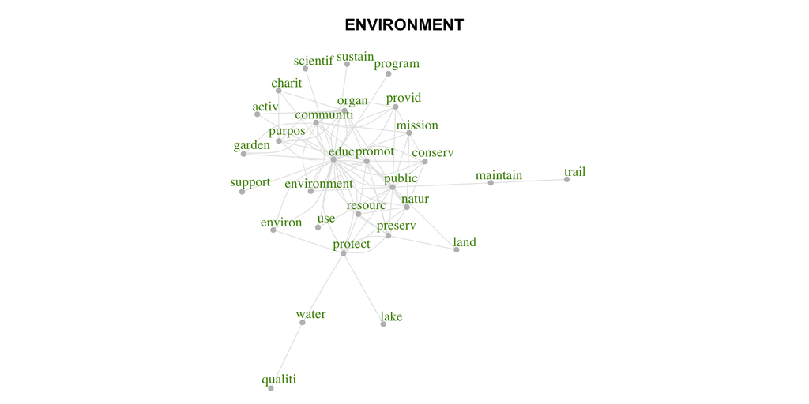

```r
par(mar = c(0, 0, 3, 0))
plot(main.component, layout = layout.kk, vertex.color = "gray", vertex.frame.color = "gray",
    edge.color = "gray90", vertex.size = 3, vertex.label.dist = 1, vertex.label.color = "chartreuse4",
    label.cex = 0.6, main = "ENVIRONMENT")
```

## Education

```r
dat$activity.code <- paste0(dat$codedef01, ": ", dat$codedef02)
grep("^education", dat$activity.code, value = TRUE, ignore.case = T) %>% head(10)
```

```
 [1] "Educational Institutions: Educational Services and Schools—Other"
 [2] "Educational Institutions: Educational Services and Schools—Other"
 [3] "Educational Institutions: Educational Services and Schools—Other"
 [4] "Educational Institutions: Educational Services and Schools—Other"
 [5] "Educational Institutions: Educational Services and Schools—Other"
 [6] "Educational Institutions: Educational Services and Schools—Other"
 [7] "Educational Institutions: Educational Services and Schools—Other"
 [8] "Educational Institutions: Educational Services and Schools—Other"
 [9] "Educational Institutions: Educational Services and Schools—Other"
[10] "Educational Institutions: Educational Services and Schools—Other"
```

```r
category4 <- grepl("^education", dat$activity.code, ignore.case = T)
sum(category4)
```

```
[1] 7603
```

```r
dat4 <- dat[category4, c("orgname", "activity.code", "mission")]
dat4 %>% head(10) %>% pander()
```

Table continues below

|  | orgname | activity.code |
| --- | --- | --- |
| **24878** | KIDSFLYCUBS ORG INC | Educational Institutions: Educational Services and Schools—Other |
| **24879** | IDAHO FALLS CHINESE SCHOOL INC | Educational Institutions: Educational Services and Schools—Other |
| **24880** | WHEN DOVES CODE | Educational Institutions: Educational Services and Schools—Other |
| **24881** | ACADEMIC SOLUTIONS USA | Educational Institutions: Educational Services and Schools—Other |
| **24882** | VERY IMPORTANT PURPOSE CORP | Educational Institutions: Educational Services and Schools—Other |
| **24883** | GIRLS CREATE | Educational Institutions: Educational Services and Schools—Other |
| **24884** | GLOBAL LIFE WONDER INC | Educational Institutions: Educational Services and Schools—Other |
| **24885** | ASSIST TO GROW INC REVENUE PROCEDURE 2014-11 REINSTATEMENT POSTMARK | Educational Institutions: Educational Services and Schools—Other |
| **24886** | THE EDUCATIONAL GLOBAL GROUP | Educational Institutions: Educational Services and Schools—Other |
| **24887** | TEENS CLOSE THE GAP | Educational Institutions: Educational Services and Schools—Other |

|  | mission |
| --- | --- |
| **24878** | KidsFLyCubs.org INC is an nonprofit educational organization dedicated to promoting tailwheel flying in America’s Future Aviators through flight and ground training provided at no cost to participants |
| **24879** | Idaho Falls Chinese School Inc is a non-profit, non-religious, cultural education institution, in pursuit of teaching Chinese language and Chinese culture, and engaging in cultural-awareness activitie… |
| **24880** | Provide extra-curricular computer science education to middle and high school students; plus professional development for teachers who want guidance with learning or developing curriculum to improve c… |
| **24881** | We raise funds for and bring Irlen Syndrome Screening and comprehensive gifted programming to schools and school districts free of charge. |
| **24882** | Help kids and teenager to reach their goals in life, helping them pay their private education, favorite sports, arts lessons, broadcasting classes, etc. Create events and activities to help our commun… |
| **24883** | To educate and encourage girls in grades K-12 to pursue careers in science, technology, engineering and mathematics by hosting presentations and hands-on workshops in local communities. |
| **24884** | Inspire and help individuals to focus, cultivate mindfulness and develop greater emotional intelligence through compassion, empathy and kindness. Empower and facilitate throughout the world to bring f… |
| **24885** |  |
| **24886** | The Educational Global Group’s mission is to assist rural, inner city and first generation college youth with going to college. We assist youth through the process of applying for college, searching f… |
| **24887** | PROVIDE EDUCATION SERVICES TO UNDERREPRESENTED STUDENTS. |

```r
corp.cat4 <- corpus(dat4, docid_field = "orgname", text_field = "mission")
corp.cat4
```

```
Corpus consisting of 7,603 documents and 1 docvar.
```

```r
corp.cat4[1:5]
```

```
                                                                                                                                                                                                                                        KIDSFLYCUBS ORG INC
                                                  "KidsFLyCubs.org INC is an nonprofit educational organization dedicated to promoting tailwheel flying in America's Future Aviators through flight and ground training provided at no cost to participants"
                                                                                                                                                                                                                             IDAHO FALLS CHINESE SCHOOL INC
                               "Idaho Falls Chinese School Inc is a non-profit, non-religious, cultural education institution, in pursuit of teaching Chinese language and Chinese culture, and engaging in cultural-awareness activities in the community."
                                                                                                                                                                                                                                            WHEN DOVES CODE
       "Provide extra-curricular computer science education to middle and high school students; plus professional development for teachers who want guidance with learning or developing curriculum to improve computer science education in their schools."
                                                                                                                                                                                                                                     ACADEMIC SOLUTIONS USA
                                                                                                                "We raise funds for and bring Irlen Syndrome Screening and comprehensive gifted programming to schools and school districts free of charge."
                                                                                                                                                                                                                                VERY IMPORTANT PURPOSE CORP
"Help kids and teenager to reach their goals in life, helping them pay their private education, favorite sports, arts lessons, broadcasting classes, etc. Create events and activities to help our community and at the same time students can receive serv"
```

```r
# summarize corpus
summary(corp.cat4)[1:10, ]
```

```
                                                                  Text Types
1                                                 KIDSFLYCUBS ORG INC     26
2                                      IDAHO FALLS CHINESE SCHOOL INC     26
3                                                     WHEN DOVES CODE     30
4                                              ACADEMIC SOLUTIONS USA     20
5                                         VERY IMPORTANT PURPOSE CORP     38
6                                                        GIRLS CREATE     24
7                                              GLOBAL LIFE WONDER INC     28
8  ASSIST TO GROW INC REVENUE PROCEDURE 2014-11 REINSTATEMENT POSTMARK     0
9                                        THE EDUCATIONAL GLOBAL GROUP     33
10                                                TEENS CLOSE THE GAP      7
   Tokens Sentences
1      27         1
2      34         1
3      34         1
```

[output cut: 18 more lines]

```r
# pre-processing steps:

# remove mission statements that are less than 3 sentences long
corp.cat4 <- corpus_trim(corp.cat4, what = "sentences", min_ntoken = 3)
corp.cat4
```

```
Corpus consisting of 6,932 documents and 1 docvar.
```

```r
# remove punctuation
tokens.cat4 <- tokens(corp.cat4, what = "word", remove_punct = TRUE)

# convert to lower case
tokens.cat4 <- tokens_tolower(tokens.cat4, keep_acronyms = FALSE)
head(tokens.cat4)
```

```
tokens from 6 documents.
KIDSFLYCUBS ORG INC  :
 [1] "kidsflycubs.org" "inc"             "is"              "an"
 [5] "nonprofit"       "educational"     "organization"    "dedicated"
 [9] "to"              "promoting"       "tailwheel"       "flying"
[13] "in"              "america's"       "future"          "aviators"
[17] "through"         "flight"          "and"             "ground"
[21] "training"        "provided"        "at"              "no"
[25] "cost"            "to"              "participants"

IDAHO FALLS CHINESE SCHOOL INC  :
 [1] "idaho"              "falls"              "chinese"
 [4] "school"             "inc"                "is"
 [7] "a"                  "non-profit"         "non-religious"
[10] "cultural"           "education"          "institution"
```

[output cut: 43 more lines]

```r
tokens.cat4 <- tokens_remove(tokens.cat4, c(stopwords("english"), "nbsp"), padding = F)
head(tokens.cat4)
```

```
tokens from 6 documents.
KIDSFLYCUBS ORG INC  :
 [1] "kidsflycubs.org" "inc"             "nonprofit"       "educational"
 [5] "organization"    "dedicated"       "promoting"       "tailwheel"
 [9] "flying"          "america's"       "future"          "aviators"
[13] "flight"          "ground"          "training"        "provided"
[17] "cost"            "participants"

IDAHO FALLS CHINESE SCHOOL INC  :
 [1] "idaho"              "falls"              "chinese"
 [4] "school"             "inc"                "non-profit"
 [7] "non-religious"      "cultural"           "education"
[10] "institution"        "pursuit"            "teaching"
[13] "chinese"            "language"           "chinese"
[16] "culture"            "engaging"           "cultural-awareness"
```

[output cut: 30 more lines]

```r
my_dictionary4 <- dictionary(list(five01_c_3 = c("501 c 3", "section 501 c 3"), united_states = c("united states"),
    high_school = c("high school"), middle_school = c("middle school"), elementary_school = c("elementary school"),
    non_profit = c("non-profit", "non profit"), stem = c("science technology engineering math",
        "science technology engineering mathematics"), los_angeles = c("los angeles"),
    ny_state = c("new york state"), ny = c("new york"), san_francisco = c("san francisco"),
    san_diego = c("san diego"), north_carolina = c("north carolina"), south_carolina = c("south carolina"),
    dc = c("district of columbia"), north_dakota = c("north dakota"), south_dakota = c("south dakota"),
    west_virginia = c("west virginia"), new_mexico = c("new mexico"), new_hampshire = c("new hampshire"),
    new_jersey = c("new jersey"), new_england = c("new england"), high_quality = c("high-quality",
        "high quality"), low_income = c("low income", "low-income"), early_childhood = c("early childhood",
        "early-childhood"), community_based = c("community-based", "community based"),
    mission_driven = c("mission-driven", "mission driven"), ses = c("socioeconomic status"),
    performing_arts = c("performing arts"), extracurricular = c("extra curricular")))

# apply the dictionary to the text
tokens.cat4 <- tokens_compound(tokens.cat4, pattern = my_dictionary4)
head(tokens.cat4)
```

```
tokens from 6 documents.
KIDSFLYCUBS ORG INC  :
 [1] "kidsflycubs.org" "inc"             "nonprofit"       "educational"
 [5] "organization"    "dedicated"       "promoting"       "tailwheel"
 [9] "flying"          "america's"       "future"          "aviators"
[13] "flight"          "ground"          "training"        "provided"
[17] "cost"            "participants"

IDAHO FALLS CHINESE SCHOOL INC  :
 [1] "idaho"              "falls"              "chinese"
 [4] "school"             "inc"                "non-profit"
 [7] "non-religious"      "cultural"           "education"
[10] "institution"        "pursuit"            "teaching"
[13] "chinese"            "language"           "chinese"
[16] "culture"            "engaging"           "cultural-awareness"
```

[output cut: 39 more lines]

```r
# stem the words in the token list:
tokens.cat4 <- tokens_wordstem(tokens.cat4)
```

```r
# find frequently co-occuring words (typically compound words)
ngram2d <- tokens_ngrams(tokens.cat4, n = 2) %>% dfm()
ngram2d %>% textstat_frequency(n = 10)
```

```
              feature frequency rank docfreq group
1         provid_educ       380    1     378   all
2           rais_fund       346    2     343   all
3      parent_teacher       338    3     318   all
4        support_educ       310    4     308   all
5  provid_scholarship       274    5     273   all
6     financi_support       227    6     224   all
7        educ_program       194    7     191   all
8      provid_financi       184    8     182   all
9     school_district       177    9     167   all
10        educ_purpos       177    9     177   all
```

```r
ngram3d <- tokens_ngrams(tokens.cat4, n = 3) %>% dfm()
ngram3d %>% textstat_frequency(n = 10)
```

```
                         feature frequency rank docfreq group
1             charit_educ_purpos       100    1     100   all
2          school_parent_teacher        95    2      94   all
3            organ_exclus_charit        94    3      94   all
4           parent_teacher_organ        89    4      88   all
5             exclus_charit_educ        80    5      80   all
6         provid_financi_support        78    6      76   all
7             intern_revenu_code        78    6      77   all
8            enhanc_support_educ        78    6      78   all
9            support_educ_experi        76    9      76   all
10 section_501_c_3_intern_revenu        68   10      68   all
```

```r
tokens.cat4 %>% dfm(stem = F) %>% topfeatures()
```

```
     educ    provid   support   student    school     organ communiti   program
     4407      2855      2513      2417      2076      1876      1518      1336
   purpos    promot
     1157      1093
```

```r
tokens.cat4 %>% dfm(stem = T) %>% topfeatures()
```

```
     educ    provid   support   student    school     organ communiti   program
     4407      2855      2513      2417      2076      1876      1518      1336
    purpo    promot
     1157      1093
```

### Part Two:

```r
edu.token.list <- as.list(tokens.cat4)
edu.token.list <- lapply(edu.token.list, function(x) {
    x[!grepl("^$", x)]
})
edu.token.list[[1]]
```

```
 [1] "kidsflycubs.org" "inc"             "nonprofit"       "educ"
 [5] "organ"           "dedic"           "promot"          "tailwheel"
 [9] "fli"             "america"         "futur"           "aviat"
[13] "flight"          "ground"          "train"           "provid"
[17] "cost"            "particip"
```

```r
listToNet <- function(x) {

    word.pairs <- list()

    for (i in 1:length(x)) {
        x.i <- x[[i]]
        word.pairs[[i]] <- NULL
        if (length(x.i) > 1) {
            word.pairs[[i]] <- data.frame(t(combn(x.i, 2)), stringsAsFactors = F)
            names(word.pairs[[i]]) <- c("from", "to")
        }

    }

    return(word.pairs)

}

g.list3 <- listToNet(edu.token.list)
head(g.list3[[1]])
```

```
             from        to
1 kidsflycubs.org       inc
2 kidsflycubs.org nonprofit
3 kidsflycubs.org      educ
4 kidsflycubs.org     organ
5 kidsflycubs.org     dedic
6 kidsflycubs.org    promot
```

```r
# number of separate mission statements in the list
length(g.list3)
```

```
[1] 6932
```

```r
g.list.edu <- listToNet(edu.token.list)
df.edu <- bind_rows(g.list.edu)
class(df.edu)
```

```
[1] "data.frame"
```

```r
dim
```

```
function (x)  .Primitive("dim")
```

```r
head(df.edu)
```

```
             from        to
1 kidsflycubs.org       inc
2 kidsflycubs.org nonprofit
3 kidsflycubs.org      educ
4 kidsflycubs.org     organ
5 kidsflycubs.org     dedic
6 kidsflycubs.org    promot
```

Count ties:

```r
ties3 <- paste0(df.edu$from, "-", df.edu$to)
head(ties3)
```

```
[1] "kidsflycubs.org-inc"       "kidsflycubs.org-nonprofit"
[3] "kidsflycubs.org-educ"      "kidsflycubs.org-organ"
[5] "kidsflycubs.org-dedic"     "kidsflycubs.org-promot"
```

```r
table(ties3) %>% sort() %>% tail()
```

```
ties3
provid-student      educ-educ   educ-student   support-educ     organ-educ
           869            908            921            951           1038
   provid-educ
          1472
```

Count tie prevelance:

```r
table(table(ties3))  # count of the count of ties: prevelance of frequencies
```

```
     1      2      3      4      5      6      7      8      9     10     11
283847  62814  21512  11197   6418   4310   2967   2223   1754   1345   1047
    12     13     14     15     16     17     18     19     20     21     22
   901    771    642    494    461    439    344    323    301    275    251
    23     24     25     26     27     28     29     30     31     32     33
   220    204    179    135    167    144    132    110    101    126     84
    34     35     36     37     38     39     40     41     42     43     44
    73     80     93     84     69     73     72     61     54     58     53
    45     46     47     48     49     50     51     52     53     54     55
    53     35     52     46     35     35     37     29     16     39     30
    56     57     58     59     60     61     62     63     64     65     66
    30     20     20     18     25     23     24     23     22     14     16
    67     68     69     70     71     72     73     74     75     76     77
    23     17     20     28     25     16     14     20     14     15     18
    78     79     80     81     82     83     84     85     86     87     88
```

[output cut: 24 more lines]

```r
# 99% of ties occur less than 6 times
table(table(ties3)) %>% prop.table() %>% round(2)
```

```
   1    2    3    4    5    6    7    8    9   10   11   12   13   14   15   16
0.69 0.15 0.05 0.03 0.02 0.01 0.01 0.01 0.00 0.00 0.00 0.00 0.00 0.00 0.00 0.00
  17   18   19   20   21   22   23   24   25   26   27   28   29   30   31   32
0.00 0.00 0.00 0.00 0.00 0.00 0.00 0.00 0.00 0.00 0.00 0.00 0.00 0.00 0.00 0.00
  33   34   35   36   37   38   39   40   41   42   43   44   45   46   47   48
0.00 0.00 0.00 0.00 0.00 0.00 0.00 0.00 0.00 0.00 0.00 0.00 0.00 0.00 0.00 0.00
  49   50   51   52   53   54   55   56   57   58   59   60   61   62   63   64
0.00 0.00 0.00 0.00 0.00 0.00 0.00 0.00 0.00 0.00 0.00 0.00 0.00 0.00 0.00 0.00
  65   66   67   68   69   70   71   72   73   74   75   76   77   78   79   80
0.00 0.00 0.00 0.00 0.00 0.00 0.00 0.00 0.00 0.00 0.00 0.00 0.00 0.00 0.00 0.00
  81   82   83   84   85   86   87   88   89   90   91   92   93   94   95   96
0.00 0.00 0.00 0.00 0.00 0.00 0.00 0.00 0.00 0.00 0.00 0.00 0.00 0.00 0.00 0.00
  97   98   99  100  101  102  103  104  105  106  107  108  109  110  111  112
0.00 0.00 0.00 0.00 0.00 0.00 0.00 0.00 0.00 0.00 0.00 0.00 0.00 0.00 0.00 0.00
 113  114  115  116  117  118  119  120  121  122  123  124  125  126  127  128
0.00 0.00 0.00 0.00 0.00 0.00 0.00 0.00 0.00 0.00 0.00 0.00 0.00 0.00 0.00 0.00
 129  130  131  132  133  134  135  136  137  138  139  140  141  142  143  144
0.00 0.00 0.00 0.00 0.00 0.00 0.00 0.00 0.00 0.00 0.00 0.00 0.00 0.00 0.00 0.00
 145  146  147  148  149  151  152  153  154  155  156  157  158  160  161  162
0.00 0.00 0.00 0.00 0.00 0.00 0.00 0.00 0.00 0.00 0.00 0.00 0.00 0.00 0.00 0.00
 163  164  165  166  167  168  169  170  172  173  174  175  176  177  178  180
0.00 0.00 0.00 0.00 0.00 0.00 0.00 0.00 0.00 0.00 0.00 0.00 0.00 0.00 0.00 0.00
 183  184  185  186  189  190  191  192  193  194  195  196  197  198  199  202
0.00 0.00 0.00 0.00 0.00 0.00 0.00 0.00 0.00 0.00 0.00 0.00 0.00 0.00 0.00 0.00
 204  205  207  208  209  210  211  214
0.00 0.00 0.00 0.00 0.00 0.00 0.00 0.00
 [ reached getOption("max.print") -- omitted 110 entries ]
```

### Filter Graph by Tie Frequency

We can ignore word co-occurences that occur only once or twice across all missions (that would mean those two words occur together only once or twice in the sample - the co-occurence is not meaningful).

```r
df.edu$ties <- ties3

df.edu.filtered <-
   df.edu %>%
   group_by( ties ) %>%
   mutate( n=n(), same.word= to == from ) %>%  # count frequency of each tie
   filter( n > 160, ! same.word ) %>%
   ungroup() %>%
   select( from, to ) %>%
   unique()
```

Compare data sets:

```r
dim(df.edu)
```

```
[1] 980228      3
```

```r
head(df.edu)
```

```
             from        to                      ties
1 kidsflycubs.org       inc       kidsflycubs.org-inc
2 kidsflycubs.org nonprofit kidsflycubs.org-nonprofit
3 kidsflycubs.org      educ      kidsflycubs.org-educ
4 kidsflycubs.org     organ     kidsflycubs.org-organ
5 kidsflycubs.org     dedic     kidsflycubs.org-dedic
6 kidsflycubs.org    promot    kidsflycubs.org-promot
```

```r
dim(df.edu.filtered)
```

```
[1] 216   2
```

```r
head(df.edu.filtered)
```

```
# A tibble: 6 x 2
  from  to
  <chr> <chr>
1 educ  organ
2 educ  promot
3 educ  train
4 educ  provid
5 organ promot
6 organ provid
```

```r
g.edu <- graph.edgelist(as.matrix(df.edu.filtered), directed = FALSE)

dg <- decompose.graph(g.edu)  # returns a list of three graphs
main.component <- dg[[1]]

layout.kk <- layout_with_kk(main.component, kkconst = 10)
```

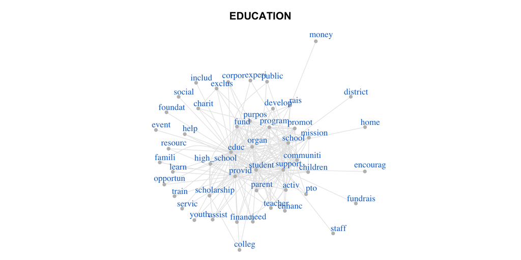

```r
par(mar = c(0, 0, 3, 0))
plot(main.component, layout = layout.kk, vertex.color = "gray", vertex.frame.color = "gray",
    edge.color = "gray90", vertex.size = 3, vertex.label.dist = 1, vertex.label.color = "dodgerblue3",
    label.cex = 0.6, main = "EDUCATION")
```

### Summary

The five most popular words across all three categories of arts, environment, and education, the most popular word variations were the following:

1. Education: 7,026
2. Provide: 4,495
3. Communities: 3,564
4. Organization: 3,299
5. Promote: 2,537

Courtney Stowers

February 25, 2020